# Презентация по лабораторной работе №3

Настройка DHCP-сервера

Лушин А.А.

Российский университет дружбы народов, Москва, Россия

Факультет Физико-математических и естественных наук

# Информация

## Докладчик

- Лушин Артём Андреевич
- Бакалавр направления компьютерные и информационные науки
- Кафедра теории вероятности и кибербезопасности
- Российский университет дружбы народов
- lusin5745@gmail.com

# Вводная часть

## Цели и задачи

Приобретение практических навыков по установке и конфигурированию DHCP-сервера.

# Ход работы

## Конфигурирование DHCP

Копируем и переносим в рабочий каталог файл dhcpd.conf. Заменяем файл под себя. Настраиваем привязку к eth1 на машине сервер. Перезагружаем конфигурацию и разрешаем загрузку DHCP при запуске. Добавляем данные в прямую и обратную днс-зону, меняем серийный номер. Проверяем, что всё работает. Изменяем межсетевой узел и восстанавливаем метки SELinux.

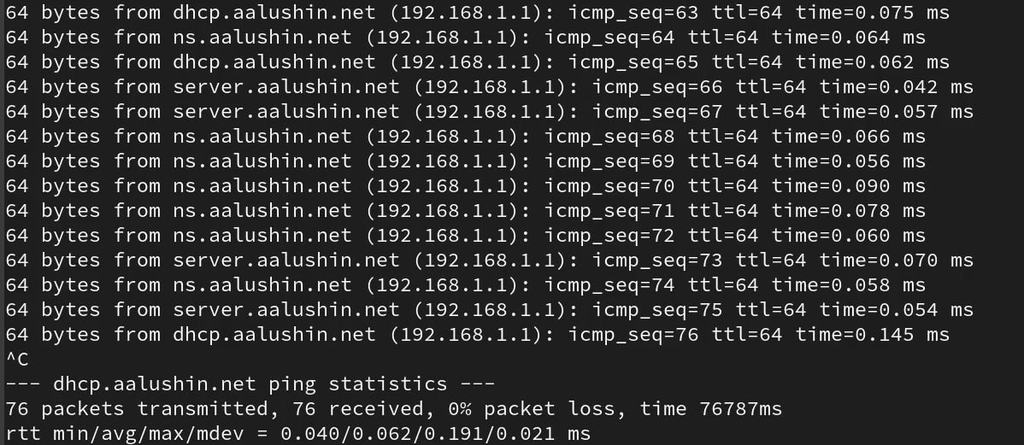

## Анализ DHCP-сервера

Меняем файлы 01-routing.sh и Vagrantfile для корректного запуска машины клиент. Зафиксировали изменения и запустили машину и ожидаем полной загрузки. На терминале машины сервер появится информация, что подключился клиент. Проверяем информацию для клиента.

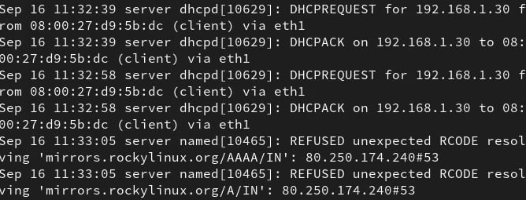

## Настройки обновления DNS-зоны

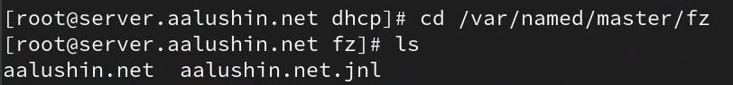

## Изменения внутреннего окружения

В каталоге сервер создаём папку dhcp в которой размещаем все конфигурационные файлы. Заменяем конфигурационный файл DNS-сервера. Создал исполняемый файл dhcp.sh и прописал скрипт, который будет повторять все произведённые действия. Изменил Vagrantfile, чтобы скрипт отрабатывал при запуске машины.

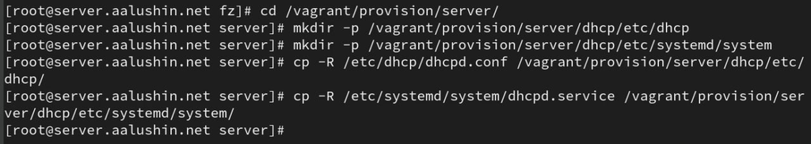

# Результаты

## Вывод

Я приобрёл практические навыки по установке и конфигурированию DHCP-сервера.

## Контрольные вопросы

1. В каких файлах хранятся настройки сетевых подключений?
- Конфигурация сетевого интерфейса хранится в /etc/sysconfig/network-scripts в соответствующем файле с префиксом ifcfg (там же конфигурационные файлы других интерфейсов).
2. За что отвечает протокол DHCP?
- Протокол DHCP (Dynamic Host Configuration Protocol) отвечает за автоматическую настройку IP-адресов и других сетевых параметров для устройств в сети.
3. Поясните принцип работы протокола DHCP. Какими сообщениями обмениваются клиент и сервер, используя протокол DHCP?
- Протокол DHCP работает по принципу клиент-серверной модели. Когда клиент подключается к сети, он отправляет DHCP-запрос на сервер, запрашивая IP-адрес и другие сетевые настройки. Сервер DHCP выделяет IP-адрес из своего пула доступных адресов и отправляет его клиенту вместе с другими настройками в сообщении DHCP-ответа.
4. В каких файлах обычно находятся настройки DHCP-сервера? За что отвечает каждый из файлов?
- Настройки хранятся в файле dhcpd.conf, а именно конфигурация dhcp-сети(адрес подсети, диапазон адресов для распределения клиентам, адрес маршрутизатора и broadcast-адрес), также доменное имя и его серверы. В файле dhcpd.service прописана привязка dhcpd к интерфейсу.
5. Что такое DDNS? Для чего применяется DDNS?
- DDNS (Dynamic Domain Name System) – это система, которая позволяет автоматически обновлять записи DNS при изменении IP-адресов устройств в сети. DDNS обеспечивает привязку доменных имен к динамически изменяющимся IP-адресам, что позволяет обращаться к сетевым ресурсам по именам, не зависящим от их текущего IP-адреса.
6. Какую информацию можно получить, используя утилиту ifconfig? Приведите примеры с использованием различных опций
- Утилита ifconfig позволяет получить информацию о сетевых интерфейсах на компьютере, включая IP-адреса, маски подсети, MAC-адреса и другие параметры. Например, команда “ifconfig” выводит информацию о всех активных сетевых интерфейсах, а команда “ifconfig eth0” показывает информацию о конкретном сетевом интерфейсе eth0.
7. Какую информацию можно получить, используя утилиту ping? Приведите примеры с использованием различных опций.
- Утилита ping используется для проверки доступности и измерения задержки (ping) до удаленного хоста с использованием ICMP (Internet Control Message Protocol).